# Results

Carlo Carandang, Gregory Horne, William Wells, and Catherine Stokes

2017-12-10

Importing the dataset

```r
setwd("~/Desktop/Nova_Scotia_Surgical_Wait_Times")
Surgical_Wait_Times_2017_09_04 <- read.csv("data_analysis/data/Surgical_Wait_Times_2017-09-04.csv", sep="\t", header = T)
```

What does the dataset look like?

```r
head(Surgical_Wait_Times_2017_09_04)
```

```
##            Period       Specialty         Procedure         Provider
## 1 12month_rolling         Urology   Adrenal Surgery  Rendon, Ricardo
## 2 12month_rolling         Urology   Adrenal Surgery
## 3 12month_rolling         Urology   Adrenal Surgery
## 4 12month_rolling Plastic Surgery Aesthetic Surgery   Boileau, Louis
## 5 12month_rolling Plastic Surgery Aesthetic Surgery Bezuhly, Michael
## 6 12month_rolling Plastic Surgery Aesthetic Surgery Brennan, Michael
##     Zone   Facility Year Quarter Consult_Median Consult_90th
## 1                     NA      NA              8           17
## 2 Zone 4        QE2 2016       4              9           17
## 3  Total Provincial 2016       4             11           21
## 4                     NA      NA             88          163
## 5                     NA      NA             61          129
## 6                     NA      NA            136          274
##   Surgery_Median Surgery_90th
## 1            104          145
## 2             49          140
## 3             49          145
## 4             36           67
## 5            213          377
## 6            109          279
```

When viewing a sample of the dataset, we see multiple variables which are categorical, and the wait times are the only continuous variables.

Structure of the dataset

```r
str(Surgical_Wait_Times_2017_09_04)
```

```
## 'data.frame':    6843 obs. of  12 variables:
##  $ Period        : Factor w/ 11 levels "12month_rolling",..: 1 1 1 1 1 1 1 1 1 1 ...
##  $ Specialty     : Factor w/ 17 levels "","All Specialties",..: 16 16 16 14 14 14 14 14 14 14 ...
##  $ Procedure     : Factor w/ 160 levels "","Adrenal Surgery",..: 2 2 2 3 3 3 3 3 3 3 ...
##  $ Provider      : Factor w/ 297 levels "","Abdul Kadir, Najeeb Ahmed",..: 241 1 1 34 32 41 119 199 18 1 ...
##  $ Zone          : Factor w/ 7 levels "","IWK","Total",..: 1 7 3 1 1 1 1 1 1 6 ...
##  $ Facility      : Factor w/ 19 levels "","Aberdeen Hospital",..: 1 14 13 1 1 1 1 1 1 3 ...
##  $ Year          : int  NA 2016 2016 NA NA NA NA NA NA 2016 ...
##  $ Quarter       : int  NA 4 4 NA NA NA NA NA NA 4 ...
##  $ Consult_Median: int  8 9 11 88 61 136 37 NA 13 NA ...
##  $ Consult_90th  : int  17 17 21 163 129 274 37 NA 97 NA ...
##  $ Surgery_Median: int  104 49 49 36 213 109 208 101 48 60 ...
##  $ Surgery_90th  : int  145 140 145 67 377 279 294 134 152 152 ...
```

Summary of the dataset

```r
summary(Surgical_Wait_Times_2017_09_04)
```

```
##              Period                      Specialty
##  12month_rolling:2231   General Surgery       :1996
##  2015_q2        : 479                         : 953
##  2016_q2        : 478   Orthopaedic           : 820
##  2015_q3        : 475   Urology               : 728
##  2015_q4        : 475   Obstetrics/Gynaecology: 548
##  2014_q4        : 474   Plastic Surgery       : 364
##  (Other)        :2231   (Other)               :1434
##                                 Procedure                     Provider
##  All                                 : 296                        :5054
##  Hernia Repair  (Adult)              : 185   Wasserman, Lukas     :  22
##  Hernia Repair - Inguinal/Femoral    : 177   Clark, F Donald      :  18
##  Gallbladder Surgery                 : 166   Hoogerboord, C Marius:  18
##  Hysterectomy  (Cancer Not Suspected): 159   Cole, Basilon        :  17
##  Male Reproductive System Surgery    : 141   Ellsmere, James C    :  16
##  (Other)                             :5719   (Other)              :1698
##      Zone                      Facility         Year         Quarter
##        :1815                       :1815   Min.   :2014   Min.   :1.000
##  IWK   : 263   Provincial          :1322   1st Qu.:2015   1st Qu.:2.000
##  Total :1322   QE2                 : 971   Median :2016   Median :3.000
##  Zone 1: 811   Valley Regional     : 382   Mean   :2015   Mean   :2.871
##  Zone 2: 508   Dartmouth General   : 334   3rd Qu.:2016   3rd Qu.:4.000
##  Zone 3: 769   Cape Breton Regional: 324   Max.   :2016   Max.   :4.000
##  Zone 4:1355   (Other)             :1695   NA's   :1789   NA's   :1789
##  Consult_Median     Consult_90th    Surgery_Median     Surgery_90th
##  Min.   :   1.00   Min.   :   1.0   Min.   :   0.00   Min.   :   4.0
##  1st Qu.:  20.00   1st Qu.:  56.0   1st Qu.:  31.00   1st Qu.:  77.0
##  Median :  37.00   Median : 108.0   Median :  51.00   Median : 131.5
##  Mean   :  60.77   Mean   : 156.7   Mean   :  72.66   Mean   : 177.9
##  3rd Qu.:  70.00   3rd Qu.: 192.0   3rd Qu.:  88.00   3rd Qu.: 222.0
##  Max.   :2175.00   Max.   :2653.0   Max.   :1027.00   Max.   :1627.0
##  NA's   :1102      NA's   :1102     NA's   :105       NA's   :105
```

Correlation Analysis

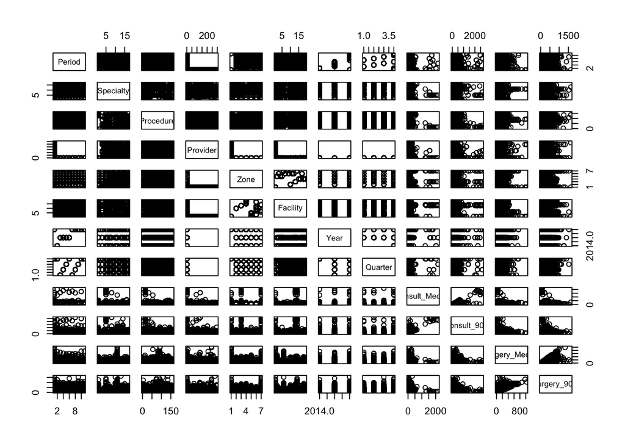

```r
pairs(Surgical_Wait_Times_2017_09_04)
```

Isolate only rows with ‘All’ Procedures - columns 2,3

```r
specialty <- Surgical_Wait_Times_2017_09_04[Surgical_Wait_Times_2017_09_04$Procedure=="All",2:12]
specialty
```

```
##                  Specialty Procedure
## 26         Cardiac Surgery       All
## 27         Cardiac Surgery       All
## 28         Cardiac Surgery       All
## 29         Cardiac Surgery       All
## 30         Cardiac Surgery       All
## 31         Cardiac Surgery       All
## 32         Cardiac Surgery       All
## 33         Cardiac Surgery       All
## 34         Cardiac Surgery       All
## 35         Cardiac Surgery       All
## 36                  Dental       All
## 37                  Dental       All
## 38                  Dental       All
## 39                  Dental       All
```

[output cut: 876 more lines]

Set independent variables:

```r
X <- specialty[,1]
X
```

```
##   [1] Cardiac Surgery        Cardiac Surgery        Cardiac Surgery
##   [4] Cardiac Surgery        Cardiac Surgery        Cardiac Surgery
##   [7] Cardiac Surgery        Cardiac Surgery        Cardiac Surgery
##  [10] Cardiac Surgery        Dental                 Dental
##  [13] Dental                 Dental                 Dental
##  [16] Dental                 Dental                 Dental
##  [19] Dental                 Dental                 Dental
##  [22] Dental                 Dental                 Dental
##  [25] Dental                 Dental                 Dental
##  [28] Dental                 Dental                 Dental
##  [31] Dental                 General Surgery        General Surgery
##  [34] General Surgery        General Surgery        General Surgery
##  [37] General Surgery        General Surgery        General Surgery
##  [40] General Surgery        General Surgery        General Surgery
##  [43] General Surgery        General Surgery        General Surgery
```

[output cut: 85 more lines]

Set dependent variable:

```r
Y <- specialty[,11]
Y
```

```
##   [1]   71   46  125   86   91   59    7   65  125   73  124  127  406  210
##  [15]  361  296  211  145  375  386   75  448  143  364  108  159  399   73
##  [29]  155  391  113  124   37  183  122   69   83  111  103  107  128   78
##  [43]  166  256  229  110  165  207  105  253   75  197  214  127  204   59
##  [57]  100  160  125   40   39  377   64   70  107  115  138   72   52   47
##  [71]   72   80   36  160  126  252   65  152  127   57   95  135   71   51
##  [85]   75   28   53  102   80  121  134  188  134  115  127   88   70  162
##  [99]  161   32   50   70  189  195  153   37   85   44   89  101  103  121
## [113]    4  197  473   89  123   98   92   56   83  134  123   96   47   59
## [127]  148  111   68   87  229   78  171   68   58  114   20   48  110  149
## [141]  190   77  133  208  244  249  217  391  104  230   67  135  202  155
## [155]  156  182  433   83  148  227  247  399  109  263  127  166  106  154
## [169]  246  218  168  251  223   79  197  251  199  400   95  264  559  438
## [183]  285  171  540  738  602  575  280  331  391  288  578  224  640  757
## [197]  862  482  226  195  311  271  139 1222  773  224  162  119  465  455
## [211]  212   92  127  266  356  286  358  184  528  269  440  456  652  111
## [225]  180  240  187  112  230  412  357  351  213  136  134   80  484  288
## [239]  228  189  134  263  225  126  163  235  391  326  117   71   95  202
## [253]  249   40  299   78  199  263   76  251  134  261  113  344   87  138
## [267]   50   92  172   74   40   92  122  104  103   99  175  322  217  412
## [281]  184  124  162  125  184  131   97   68  134  363   62  145  179  107
## [295]  141  335
```

Linear Regression

```r
model <- data.frame(X,Y)
mod.specialty <- lm(formula = Y ~ X, data = model)
summary(mod.specialty)
```

```
##
## Call:
## lm(formula = Y ~ X, data = model)
##
## Residuals:
##     Min      1Q  Median      3Q     Max
## -313.89  -65.82  -15.80   47.59  816.11
##
## Coefficients:
##                         Estimate Std. Error t value Pr(>|t|)
## (Intercept)                74.80      39.27   1.905 0.057826 .
## XDental                   166.58      47.71   3.491 0.000557 ***
## XGeneral Surgery           44.00      42.63   1.032 0.302879
## XNeurosurgery              41.10      55.54   0.740 0.459880
## XObstetrics/Gynaecology    35.08      43.60   0.805 0.421663
## XOphthalmology            122.41      44.83   2.731 0.006715 **
## XOral Maxillofacial       192.29      54.26   3.544 0.000461 ***
## XOrthopaedic              331.09      44.14   7.502 8.18e-13 ***
## XOtolaryngology (ENT)     170.04      46.47   3.660 0.000301 ***
## XPlastic Surgery          102.60      50.70   2.024 0.043934 *
## XThoracic Surgery          62.53      64.13   0.975 0.330327
## XUrology                   84.47      47.36   1.784 0.075565 .
## XVascular Surgery          86.70      64.13   1.352 0.177460
## ---
## Signif. codes:  0 '***' 0.001 '**' 0.01 '*' 0.05 '.' 0.1 ' ' 1
##
## Residual standard error: 124.2 on 283 degrees of freedom
## Multiple R-squared:  0.3872, Adjusted R-squared:  0.3612
## F-statistic:  14.9 on 12 and 283 DF,  p-value: < 2.2e-16
```

ANOVA- Analysis of Variance

```r
anova(mod.specialty)
```

```
## Analysis of Variance Table
##
## Response: Y
##            Df  Sum Sq Mean Sq F value    Pr(>F)
## X          12 2757247  229771  14.899 < 2.2e-16 ***
## Residuals 283 4364281   15421
## ---
## Signif. codes:  0 '***' 0.001 '**' 0.01 '*' 0.05 '.' 0.1 ' ' 1
```

N = 296, k (number of X variables) = 12

```r
print("The standard error of the estimate:")
```

```
## [1] "The standard error of the estimate:"
```

```r
(4364281/(296-12-1))^0.5
```

```
## [1] 124.1833
```

The standard error of the estimate is 124.2, where it is the standard deviation of the variation of observations around the regression line (it is the standard deviation of the regression model). So waitimes average can be estimated as +-2(124.2) = 248.4. As this value is large when compared to the average waittimes in the sample, then the variation of observed y values from the regression line is also large. For future research, we should look for other variables which can explain more of the variation in waittimes (ie. costs for procedures, facilities funding, staffing levels, etc.).

Multiple Coefficient of Determination: SST = SSE + SSR

```r
SST <- 4364281 + 2757247
print("R^2 =")
```

```
## [1] "R^2 ="
```

```r
2757247/SST
```

```
## [1] 0.3871707
```

R^2 is 0.3872, but we do have to utilize the adjusted R^2, as we have multiple independent variables. The adjusted R^2 is 0.3612, where 36.12% of the variation in waittimes is explained by the variation in specialty, taking into account the sample size and number of independent variables

Is the Model Significant? Hypotheses: H0: β1 = β2 = … = βk = 0 (no linear relationship) HA: at least one βi ≠ 0 (at least one independent variable affects y) F statistic = (SSR/k)/(SSE/(n-k-1))

```r
print("F statistic=")
```

```
## [1] "F statistic="
```

```r
(2757247/12)/(4364281/(296-12-1))
```

```
## [1] 14.89938
```

```r
print("F(critical)=")
```

```
## [1] "F(critical)="
```

```r
qf(0.05, 12, 283, lower.tail = F)
```

```
## [1] 1.786487
```

Since F = 14.9 is in the rejection region (it is greater than the F(critical) = 1.79), we reject the null hypothesis at alpha = 0.05, and accept the alternative hypothesis that at least one independent variable affects waittimes at 95% confidence. So we conclude that the regression model does explain a significant portion of the variation in waittimes. This conclusion is also confirmed by the F-statistic with a p-value: < 2.2e-16, and therefore it is less than the alpha value of 0.05, and we can also conclude from this p-value that the model does explain a significant portion of the variation in waittimes.

Here is the prediction model:

waittimes = 74.8 + 166.58(Dental) + 44(General Surgery) + 41.10(Neurosurgery) 35.08(Obstetrics/Gynaecology) + 122.41(Opthalmology) + 192.29(Oral Maxillofacial) + 331.09(Orthopaedic) + 170.04(Otolaryngology (ENT)) + 102.60(Plastic Surgery) + 62.53(Thoracic Surgery) + 84.47(Urology) + 86.70(Vascular Surgery)

Cardiac Surgery is the default, where all the other specialty variables are 0.

The model predicts the following for average wait times by specialty:

```r
print("The average Cardiac Surgery wait time in Nova Scotia is:")
```

```
## [1] "The average Cardiac Surgery wait time in Nova Scotia is:"
```

```r
74.80
```

```
## [1] 74.8
```

```r
print("The average Dental wait time in Nova Scotia is:")
```

```
## [1] "The average Dental wait time in Nova Scotia is:"
```

```r
74.80 + 166.58
```

```
## [1] 241.38
```

```r
print("The average General Surgery wait time in Nova Scotia is:")
```

```
## [1] "The average General Surgery wait time in Nova Scotia is:"
```

```r
74.80 + 44
```

```
## [1] 118.8
```

```r
print("The average Obstetrics/Gynaecology wait time in Nova Scotia is:")
```

```
## [1] "The average Obstetrics/Gynaecology wait time in Nova Scotia is:"
```

```r
74.80 + 35.08
```

```
## [1] 109.88
```

```r
print("The average Ophthalmology wait time in Nova Scotia is:")
```

```
## [1] "The average Ophthalmology wait time in Nova Scotia is:"
```

```r
74.80 + 122.41
```

```
## [1] 197.21
```

```r
print("The average Oral Maxillofacial wait time in Nova Scotia is:")
```

```
## [1] "The average Oral Maxillofacial wait time in Nova Scotia is:"
```

```r
74.80 + 192.29
```

```
## [1] 267.09
```

```r
print("The average Orthopaedic wait time in Nova Scotia is:")
```

```
## [1] "The average Orthopaedic wait time in Nova Scotia is:"
```

```r
74.80 + 331.09
```

```
## [1] 405.89
```

```r
print("The average Otolaryngology (ENT) wait time in Nova Scotia is:")
```

```
## [1] "The average Otolaryngology (ENT) wait time in Nova Scotia is:"
```

```r
74.80 + 170.04
```

```
## [1] 244.84
```

```r
print("The average Plastic Surgery wait time in Nova Scotia is:")
```

```
## [1] "The average Plastic Surgery wait time in Nova Scotia is:"
```

```r
74.80 + 102.60
```

```
## [1] 177.4
```

```r
print("The average Thoracic Surgery wait time in Nova Scotia is:")
```

```
## [1] "The average Thoracic Surgery wait time in Nova Scotia is:"
```

```r
74.80 + 62.53
```

```
## [1] 137.33
```

```r
print("The average Urology wait time in Nova Scotia is:")
```

```
## [1] "The average Urology wait time in Nova Scotia is:"
```

```r
74.80 + 84.47
```

```
## [1] 159.27
```

```r
print("The average Vascular Surgery wait time in Nova Scotia is:")
```

```
## [1] "The average Vascular Surgery wait time in Nova Scotia is:"
```

```r
74.80 + 86.70
```

```
## [1] 161.5
```

Although we can give an estimate of average wait times in Nova Scotia based on specialty from the model, only the waittimes from the following specialties are statistically significant: Dental, Opthalmology, Oral Maxillofacial, Orthopaedic, Otolaryngology (ENT), and Plastic Surgery at 95% confidence. However, Cardiac Surgery (p = 0.06) and Urology (p = 0.08) are almost at 0.05, so the wait times for these specialties are close to being statistically significant.

However, the above only has part of the wait times…the total wait includes consult wait time and surgical wait time, so we have to also add the consult wait times.

See data_analysis.rmd file in folder /data_analysis for the analysis which includes the total wait times of the sum of consult wait times and surgical wait times.